# Assignment 2 - Wrangling Danish Kings

Asta Hoegh Gregersen

2026-12-03

```r
knitr::opts_chunk$set(echo = TRUE)
```

## Load the kings

1. Look at the dataset that are you loading and check what its columns are separated by? (hint: open it in plain text editor to see)

The dataset I am loading contains columns separated by the seperator ;

2. Create a `kings` object in R with the different functions below and inspect the different outputs.
- read.csv()´
- `read_csv()`
- `read.csv2()`
- `read_csv2()`

```r
# Reviewing the output of different functions
# Loading the library
library(tidyverse)
kings1 <- read.csv("data/kongerækken_helt_ny_13_3.csv")
kings1
```

```
##    regent.gender..birth.death.first_year_ruled.last_year_ruled.no_years_ruled
## 1                                        Frederik_10;mand ;1968;NA;2024;NA;NA
## 2                                    Margrethe_2;kvinde;1940;NA ;1972;2024;52
## 3                                     Frederik_9;mand ;1899;1972;1947;1972;25
## 4                                   Christian_10;mand ;1870;1947;1912;1947;35
## 5                                      Frederik_8;mand ;1843;1912;1906;1912;6
## 6                                    Christian_9;mand ;1818;1906;1863;1906;43
## 7                                    Frederik_7 ;mand ;1808;1863;1848;1863;15
## 8                                     Christian_8;mand ;1786;1848;1839;1848;9
## 9                                     Frederik_6;mand ;1768;1839;1808;1839;31
## 10                                   Christian_7;mand ;1749;1808;1766;1808;42
## 11                                    Frederik_5;mand ;1723;1766;1746;1766;20
## 12                                   Christian_6;mand ;1699;1746;1730;1746;16
## 13                                    Frederik_4;mand ;1671;1730;1699;1730;31
## 14                                  Christian_5 ;mand ;1646;1699;1670;1699;29
```

[output cut: 42 more lines]

```r
kings2 <- read_csv("data/kongerækken_helt_ny_13_3.csv")
kings2
```

```
## # A tibble: 56 × 1
##    `regent;gender ;birth;death;first_year_ruled;last_year_ruled;no_years_ruled`
##    <chr>
##  1 Frederik_10;mand ;1968;NA;2024;NA;NA
##  2 Margrethe_2;kvinde;1940;NA ;1972;2024;52
##  3 Frederik_9;mand ;1899;1972;1947;1972;25
##  4 Christian_10;mand ;1870;1947;1912;1947;35
##  5 Frederik_8;mand ;1843;1912;1906;1912;6
##  6 Christian_9;mand ;1818;1906;1863;1906;43
##  7 Frederik_7 ;mand ;1808;1863;1848;1863;15
##  8 Christian_8;mand ;1786;1848;1839;1848;9
##  9 Frederik_6;mand ;1768;1839;1808;1839;31
## 10 Christian_7;mand ;1749;1808;1766;1808;42
## # ℹ 46 more rows
```

```r
kings3 <- read.csv2("data/kongerækken_helt_ny_13_3.csv")
kings3
```

```
##                     regent  gender birth death first_year_ruled last_year_ruled
## 1              Frederik_10   mand   1968  <NA>             2024              NA
## 2              Margrethe_2  kvinde  1940   NA              1972            2024
## 3               Frederik_9   mand   1899  1972             1947            1972
## 4             Christian_10   mand   1870  1947             1912            1947
## 5               Frederik_8   mand   1843  1912             1906            1912
## 6              Christian_9   mand   1818  1906             1863            1906
## 7              Frederik_7    mand   1808  1863             1848            1863
## 8              Christian_8   mand   1786  1848             1839            1848
## 9               Frederik_6   mand   1768  1839             1808            1839
## 10             Christian_7   mand   1749  1808             1766            1808
## 11              Frederik_5   mand   1723  1766             1746            1766
## 12             Christian_6   mand   1699  1746             1730            1746
## 13              Frederik_4   mand   1671  1730             1699            1730
## 14            Christian_5    mand   1646  1699             1670            1699
```

[output cut: 99 more lines]

```r
kings4 <- read_csv2( "data/kongerækken_helt_ny_13_3.csv")
```

```
## ℹ Using "','" as decimal and "'.'" as grouping mark. Use `read_delim()` for more control.
```

```r
kings4
```

```
## # A tibble: 56 × 7
##    regent     gender birth death first_year_ruled last_year_ruled no_years_ruled
##    <chr>      <chr>  <dbl> <dbl>            <dbl>           <dbl>          <dbl>
##  1 Frederik_… mand    1968    NA             2024              NA             NA
##  2 Margrethe… kvinde  1940    NA             1972            2024             52
##  3 Frederik_9 mand    1899  1972             1947            1972             25
##  4 Christian… mand    1870  1947             1912            1947             35
##  5 Frederik_8 mand    1843  1912             1906            1912              6
##  6 Christian… mand    1818  1906             1863            1906             43
##  7 Frederik_7 mand    1808  1863             1848            1863             15
##  8 Christian… mand    1786  1848             1839            1848              9
##  9 Frederik_6 mand    1768  1839             1808            1839             31
## 10 Christian… mand    1749  1808             1766            1808             42
## # ℹ 46 more rows
```

Answer: 1. Which of these functions is a `tidyverse` function? Read data with it below into a `kings` object The functions read_csv and read_csv2 are tidyverse functions. When used, they create tibbles. As the data in my dataset is separeted by semicolons, I use the read_csv2 function to create my ‘kings’ object.

2. What is the result of running `class()` on the `kings` object created with a tidyverse function.

One is able to the class of the object ‘kings’. One gets the result spec_tnl_df “tbl_df” “tbl” and “data.frame”. This is how, when data is read using the function read_csv2, the data is stored.

3. How many columns does the object have when created with these different functions?

Using read.csv, the object has 1 column. Using read_csv, the object once again has 1 column. Using read.csv2, the object has 7 columns. Using read_csv2, the object has 7 columns.

4. Show the dataset so that we can see how R interprets each column

```r
# My code

kings <- read_csv2("data/kongerækken_helt_ny_13_3.csv")
```

```
## ℹ Using "','" as decimal and "'.'" as grouping mark. Use `read_delim()` for more control.
```

```r
class(kings)
```

```
## [1] "spec_tbl_df" "tbl_df"      "tbl"         "data.frame"
```

```r
# Showcasing the dataset
```

```r
view(kings)


glimpse(kings)
```

```
## Rows: 56
## Columns: 7
## $ regent           <chr> "Frederik_10", "Margrethe_2", "Frederik_9", "Christia…
## $ gender           <chr> "mand", "kvinde", "mand", "mand", "mand", "mand", "ma…
## $ birth            <dbl> 1968, 1940, 1899, 1870, 1843, 1818, 1808, 1786, 1768,…
## $ death            <dbl> NA, NA, 1972, 1947, 1912, 1906, 1863, 1848, 1839, 180…
## $ first_year_ruled <dbl> 2024, 1972, 1947, 1912, 1906, 1863, 1848, 1839, 1808,…
## $ last_year_ruled  <dbl> NA, 2024, 1972, 1947, 1912, 1906, 1863, 1848, 1839, 1…
## $ no_years_ruled   <dbl> NA, 52, 25, 35, 6, 43, 15, 9, 31, 42, 20, 16, 31, 29,…
```

## Calculate the duration of reign for all the kings in your table

```r
# My code

kings <- kings %>%
  mutate(duration=last_year_ruled - first_year_ruled)

kings[[8]]
```

```
##  [1] NA 52 25 35  6 43 15  9 31 42 20 16 31 29 22 52 29 23 10 10 31 33  8 43  9
## [26] 12 35  3  3  7 33 27  7  2  9 39 20 25 11 11 11  9  3 30  8  9  6  6 27  5
## [51]  7 17  4 NA NA NA
```

## Calculate the average duration of reign for all rulers

```r
# Using the mean() function on the duration column as a vector
kings[[8]]
```

```
##  [1] NA 52 25 35  6 43 15  9 31 42 20 16 31 29 22 52 29 23 10 10 31 33  8 43  9
## [26] 12 35  3  3  7 33 27  7  2  9 39 20 25 11 11 11  9  3 30  8  9  6  6 27  5
## [51]  7 17  4 NA NA NA
```

```r
mean(kings$duration,na.rm=TRUE)
```

```
## [1] 19.42308
```

```r
# One gets the average 19,42308


# Using the summarise() function on the duration column as a tibble

kings %>%
  summarise(mean_duration=mean(duration,na.rm=TRUE))
```

```
## # A tibble: 1 × 1
##   mean_duration
##           <dbl>
## 1          19.4
```

```r
# One gets a new tibble with 1 row, that row is called mean_duration, it contains the average reign, and it is 19,42308
```

## How many and which kings enjoyed a longer-than-average duration of reign?

```r
# My code
filter(kings,duration>19.42308)
```

```
## # A tibble: 24 × 8
##    regent     gender birth death first_year_ruled last_year_ruled no_years_ruled
##    <chr>      <chr>  <dbl> <dbl>            <dbl>           <dbl>          <dbl>
##  1 Margrethe… kvinde  1940    NA             1972            2024             52
##  2 Frederik_9 mand    1899  1972             1947            1972             25
##  3 Christian… mand    1870  1947             1912            1947             35
##  4 Christian… mand    1818  1906             1863            1906             43
##  5 Frederik_6 mand    1768  1839             1808            1839             31
##  6 Christian… mand    1749  1808             1766            1808             42
##  7 Frederik_5 mand    1723  1766             1746            1766             20
##  8 Frederik_4 mand    1671  1730             1699            1730             31
##  9 Christian… mand    1646  1699             1670            1699             29
## 10 Frederik_3 mand    1609  1670             1648            1670             22
## # ℹ 14 more rows
## # ℹ 1 more variable: duration <dbl>
```

```r
# The names of these 24 kings can be viewed using the above code

count(filter(kings,duration>19.42308))
```

```
## # A tibble: 1 × 1
##       n
##   <int>
## 1    24
```

```r
# 24 kings enjoyed a longer-than-average duration of reign
```

## How many days did the three longest-ruling monarchs rule?

```r
# My code

arrange(kings,desc(duration))
```

```
## # A tibble: 56 × 8
##    regent     gender birth death first_year_ruled last_year_ruled no_years_ruled
##    <chr>      <chr>  <dbl> <dbl>            <dbl>           <dbl>          <dbl>
##  1 Margrethe… kvinde  1940    NA             1972            2024             52
##  2 Christian… mand    1577  1648             1596            1648             52
##  3 Christian… mand    1818  1906             1863            1906             43
##  4 Erik_7_af… mand    1382  1459             1396            1439             43
##  5 Christian… mand    1749  1808             1766            1808             42
##  6 Valdemar_… mand    1170  1241             1202            1241             39
##  7 Christian… mand    1870  1947             1912            1947             35
##  8 Valdemar_… mand    1320  1375             1340            1375             35
##  9 Christian… mand    1426  1481             1448            1481             33
## 10 Erik_6_Me… mand    1274  1319             1286            1319             33
## # ℹ 46 more rows
## # ℹ 1 more variable: duration <dbl>
```

```r
arrange(kings,desc(duration)) %>%
  slice(1:3)
```

```
## # A tibble: 3 × 8
##   regent      gender birth death first_year_ruled last_year_ruled no_years_ruled
##   <chr>       <chr>  <dbl> <dbl>            <dbl>           <dbl>          <dbl>
## 1 Margrethe_2 kvinde  1940    NA             1972            2024             52
## 2 Christian_4 mand    1577  1648             1596            1648             52
## 3 Christian_9 mand    1818  1906             1863            1906             43
## # ℹ 1 more variable: duration <dbl>
```

```r
# The three longest-ruling monarchs were Margrethe the 2nd, Christian the 4th and Christian the 9th.


# Creating the column 'days'

kings <- kings %>%
  mutate(days=duration*365)
view(kings)

# A column containing every kings reign in days has been added.
# One can now use the arrange() function, and then desc(), to get the amount of days each king has reigned in descending order.

arrange(kings,desc(days)) %>%
  slice(1:3)
```

```
## # A tibble: 3 × 9
##   regent      gender birth death first_year_ruled last_year_ruled no_years_ruled
##   <chr>       <chr>  <dbl> <dbl>            <dbl>           <dbl>          <dbl>
## 1 Margrethe_2 kvinde  1940    NA             1972            2024             52
## 2 Christian_4 mand    1577  1648             1596            1648             52
## 3 Christian_9 mand    1818  1906             1863            1906             43
## # ℹ 2 more variables: duration <dbl>, days <dbl>
```

```r
# Margrethe the 2nd ruled for 18980 days, Christian the 4th reigned for 18980 days, and Christian the 9th reigned for 15695 days.
```

## Plotting the kings’ duration of reign through time

What is the long-term trend in the duration of reign among Danish monarchs?

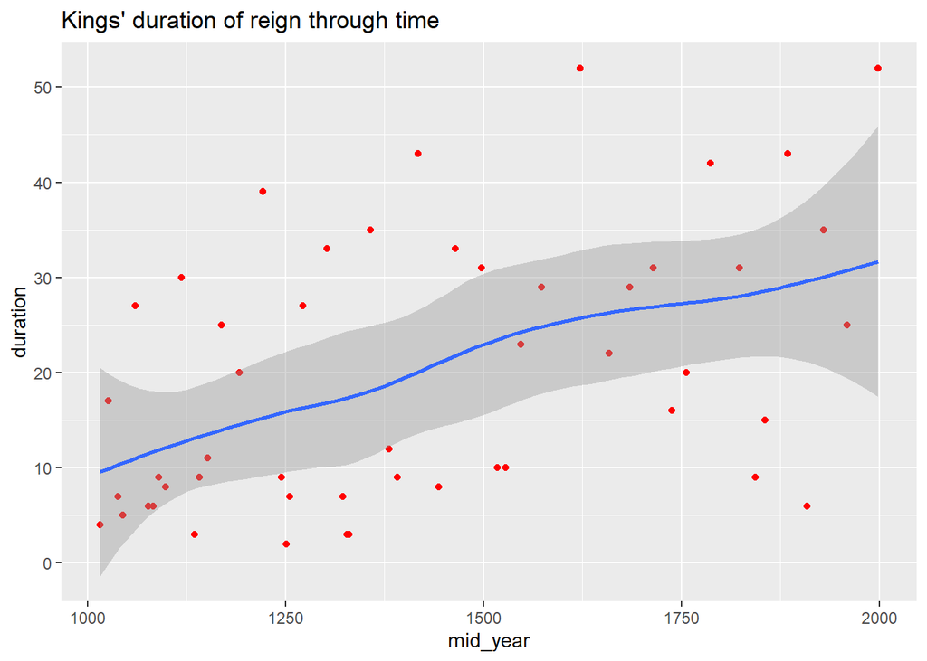

```r
kings %>% mutate(duration=last_year_ruled-first_year_ruled) %>%
  mutate(mid_year=(first_year_ruled+(last_year_ruled-first_year_ruled)/2))%>%
  ggplot(aes(x=mid_year,y=duration))+
  geom_point(color="red")+
               geom_smooth()+
  labs(title="Kings' duration of reign through time")
```

```r
               theme_minimal()
```

[output not shown]

[output cut: 313 more lines]

[output not shown]

Looking at the resulting plot, a clear trend emerges. Since the first kings, the duration of reign has steadily increased. After 1500, more kings reigned longer than the average duration of reigns, than they did before.